# Arbres de Décision

### Apprentissage vs Témoin

On va echantilloner notre base pour avoir un échantillon d’apprentissage et un échantillon témoin. On fait un tirage aléatoire et sans remise pour que 80% (seuil de base) des données constitue l’échantillon d’apprentissage. Et 20% l’échantillon de test.

```r
set.seed(200)
id_appren = sample(nrow(Ozone), floor(nrow(Ozone) * 0.80))

# Echantillon d'apprentissage
Ozone_appren = Ozone %>% slice(id_appren)

# Echantillon témoin
Ozone_test = Ozone %>% slice(-id_appren)

summary(Ozone_appren)
```

```
##        Mois       Jour_mois     Jour_semaine Concentration_Ozone
##  Juin    : 27   12     : 12   Lundi   :45    Min.   : 1.00
##  Aout    : 27   8      : 11   Mardi   :39    1st Qu.: 5.00
##  Décembre: 27   13     : 11   Mercredi:40    Median :10.00
##  Janvier : 26   22     : 11   Jeudi   :44    Mean   :11.85
##  Avril   : 26   23     : 11   Vendredi:45    3rd Qu.:17.00
##  Juillet : 26   25     : 11   Samedi  :40    Max.   :38.00
##  (Other) :133   (Other):225   Dimanche:39    NA's   :3
##  Hauteur_pression  Vitesse_vent      Humidité     Température_Sandburg
##  Min.   :5320     Min.   :0.000   Min.   :19.00   Min.   :-3.889
##  1st Qu.:5700     1st Qu.:1.864   1st Qu.:46.50   1st Qu.:11.667
##  Median :5770     Median :3.107   Median :64.00   Median :17.222
##  Mean   :5757     Mean   :3.011   Mean   :57.61   Mean   :16.977
##  3rd Qu.:5830     3rd Qu.:3.728   3rd Qu.:73.00   3rd Qu.:22.222
##  Max.   :5950     Max.   :6.835   Max.   :93.00   Max.   :33.889
##  NA's   :11                       NA's   :13      NA's   :2
##  Température_El_Monte Hauteur_couche_inversion Gradient_pression
##  Min.   :-2.40        Min.   :0.03383          Min.   :-69.00
##  1st Qu.:10.05        1st Qu.:0.26380          1st Qu.:-11.00
##  Median :14.30        Median :0.62697          Median : 23.00
##  Mean   :14.16        Mean   :0.77953          Mean   : 16.65
##  3rd Qu.:19.45        3rd Qu.:1.52400          3rd Qu.: 45.00
##  Max.   :28.10        Max.   :1.52400          Max.   :107.00
##  NA's   :105          NA's   :13               NA's   :1
##  Température_couche_inversion   Visibilité
##  Min.   :-2.50                Min.   :  0.00
##  1st Qu.:10.88                1st Qu.: 43.50
##  Median :17.15                Median : 62.14
##  Mean   :16.40                Mean   : 75.43
##  3rd Qu.:21.80                3rd Qu.: 93.21
##  Max.   :33.20                Max.   :310.69
##  NA's   :12
```

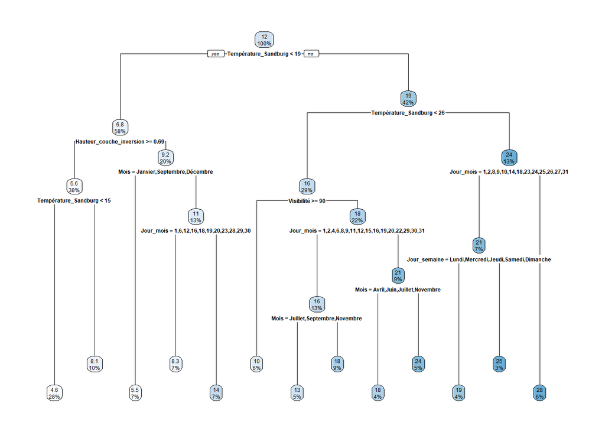

```r
tree_appren=rpart(Concentration_Ozone~., data = Ozone_appren)
rpart.plot(tree_appren)
```

### Validation du modèle

```r
rhat = tree_appren %>% predict(newdata = Ozone_test)
head(rhat)
```

```
##        6       18       19       24       30       34
##  5.52381 10.50000  5.52381  4.65000  5.52381  4.65000
```

# Partie 2

## Construction d’un arbre de classification CART sur les données de défaillances financières

### Analyse et changement de base de donnée

On charge les données de notre ancien tp sur les défaillances financières.

```r
def_finan<-read.csv("D:/2ème année/s4/Data mining/Desbois_data_origine.csv", sep = ";")
```

On regarde le résumé de la base de donnée.

```r
summary(def_finan)
```

```
##       DIFF              R1               R2               R3
##  Min.   :0.0000   Min.   :0.1190   Min.   :0.0000   Min.   :-1.5060
##  1st Qu.:0.0000   1st Qu.:0.3450   1st Qu.:0.3200   1st Qu.: 0.2167
##  Median :0.0000   Median :0.5315   Median :0.5700   Median : 0.3573
##  Mean   :0.4817   Mean   :0.5833   Mean   :0.5212   Mean   : 0.3731
##  3rd Qu.:1.0000   3rd Qu.:0.7805   3rd Qu.:0.7550   3rd Qu.: 0.5165
##  Max.   :1.0000   Max.   :3.4940   Max.   :0.9980   Max.   : 0.9999
##        R4                 R5                R6              R7
##  Min.   :-0.49400   Min.   :0.00006   Min.   :0.180   Min.   :0.00005
##  1st Qu.: 0.07925   1st Qu.:0.20500   1st Qu.:0.573   1st Qu.:0.32975
##  Median : 0.15860   Median :0.33100   Median :0.919   Median :0.55850
##  Mean   : 0.22517   Mean   :0.35608   Mean   :1.047   Mean   :0.65602
##  3rd Qu.: 0.32215   3rd Qu.:0.47150   3rd Qu.:1.365   3rd Qu.:0.87600
##  Max.   : 1.11140   Max.   :2.79200   Max.   :4.362   Max.   :3.11700
##        R8               R11                 R12                R14
##  Min.   :-0.9330   Min.   :-0.906000   Min.   :-1.16300   Min.   :-0.6850
##  1st Qu.: 0.1371   1st Qu.:-0.007698   1st Qu.:-0.01098   1st Qu.: 0.2168
##  Median : 0.2846   Median : 0.288600   Median : 0.43910   Median : 0.4637
##  Mean   : 0.3836   Mean   : 0.271290   Mean   : 0.43993   Mean   : 0.6960
##  3rd Qu.: 0.5504   3rd Qu.: 0.543325   3rd Qu.: 0.86045   3rd Qu.: 1.0148
##  Max.   : 1.8494   Max.   : 2.308300   Max.   : 3.97150   Max.   : 5.1712
##       R17               R18               R19              R21
##  Min.   :0.00599   Min.   :0.00169   Min.   :0.0170   Min.   :0.00663
##  1st Qu.:0.04480   1st Qu.:0.03050   1st Qu.:0.0999   1st Qu.:0.08885
##  Median :0.06215   Median :0.05680   Median :0.1565   Median :0.17400
##  Mean   :0.06439   Mean   :0.07060   Mean   :0.1821   Mean   :0.27997
##  3rd Qu.:0.08170   3rd Qu.:0.09552   3rd Qu.:0.2320   3rd Qu.:0.34125
##  Max.   :0.19400   Max.   :0.30000   Max.   :1.6520   Max.   :5.07900
##       R22                R24              R28              R30
##  Min.   : 0.04939   Min.   :0.0141   Min.   :0.0347   Min.   :-1.22500
##  1st Qu.: 0.29142   1st Qu.:0.1350   1st Qu.:0.2600   1st Qu.: 0.05424
##  Median : 0.49370   Median :0.1860   Median :0.3270   Median : 0.16315
##  Mean   : 0.69876   Mean   :0.1960   Mean   :0.3217   Mean   : 0.13943
##  3rd Qu.: 0.81393   3rd Qu.:0.2432   3rd Qu.:0.3890   3rd Qu.: 0.25990
##  Max.   :13.67300   Max.   :0.7460   Max.   :0.7100   Max.   : 0.58700
##       R32               R36              R37
##  Min.   :-0.1620   Min.   :0.0000   Min.   :0.1600
##  1st Qu.: 0.1724   1st Qu.:0.7905   1st Qu.:0.4600
##  Median : 0.2667   Median :1.1000   Median :0.5750
##  Mean   : 0.2510   Mean   :1.1826   Mean   :0.6109
##  3rd Qu.: 0.3377   3rd Qu.:1.4725   3rd Qu.:0.7180
##  Max.   : 0.6608   Max.   :5.0430   Max.   :2.3490
```

```r
def_finan$DIFF<-factor(def_finan$DIFF,labels=c("Pas difficultés", "Difficultés"))
str(def_finan)
```

```
## 'data.frame':    1260 obs. of  23 variables:
##  $ DIFF: Factor w/ 2 levels "Pas difficultés",..: 1 1 1 1 1 1 1 1 1 1 ...
##  $ R1  : num  0.449 0.45 0.332 0.363 0.44 0.306 0.717 0.566 0.145 0.384 ...
##  $ R2  : num  0.622 0.617 0.819 0.733 0.65 0.755 0.32 0.465 0.881 0.707 ...
##  $ R3  : num  0.255 0.241 0.557 0.36 0.314 ...
##  $ R4  : num  0.114 0.108 0.185 0.13 0.138 ...
##  $ R5  : num  0.334 0.341 0.147 0.232 0.302 0.225 0.601 0.499 0.115 0.256 ...
##  $ R6  : num  0.785 0.518 0.7 0.773 0.846 0.709 0.894 0.863 0.439 0.846 ...
##  $ R7  : num  0.585 0.393 0.31 0.495 0.58 0.523 0.748 0.761 0.348 0.563 ...
##  $ R8  : num  0.2 0.125 0.39 0.278 0.266 ...
##  $ R11 : num  0.663 0.71 0.414 0.466 0.771 ...
##  $ R12 : num  1.37 1.253 0.637 1.07 1.475 ...
##  $ R14 : num  0.232 0.15 0.485 0.373 0.256 ...
##  $ R17 : num  0.0884 0.0671 0.0445 0.0621 0.0489 0.0243 0.0352 0.0879 0.088 0.0668 ...
##  $ R18 : num  0.0694 0.0348 0.0311 0.048 0.0414 0.0173 0.0315 0.0758 0.0386 0.0565 ...
##  $ R19 : num  0.166 0.136 0.103 0.108 0.127 0.0652 0.129 0.24 0.221 0.171 ...
##  $ R21 : num  0.134 0.0802 0.089 0.0851 0.0838 0.039 0.0784 0.163 0.0711 0.155 ...
##  $ R22 : num  0.322 0.313 0.294 0.191 0.257 ...
##  $ R24 : num  0.295 0.365 0.166 0.265 0.257 0.191 0.322 0.305 0.18 0.166 ...
##  $ R28 : num  0.475 0.434 0.35 0.475 0.475 0.443 0.401 0.464 0.475 0.365 ...
##  $ R30 : num  0.35 0.298 0.247 0.376 0.367 ...
##  $ R32 : num  0.431 0.399 0.319 0.431 0.431 ...
##  $ R36 : num  0.886 0.351 1.3 1.385 0.886 ...
##  $ R37 : num  0.572 0.867 0.475 0.47 0.52 0.431 0.803 0.656 0.359 0.454 ...
```

On a donc un variable facteur et 22 variables numériques.

### Modélisation de l’arbre de classification

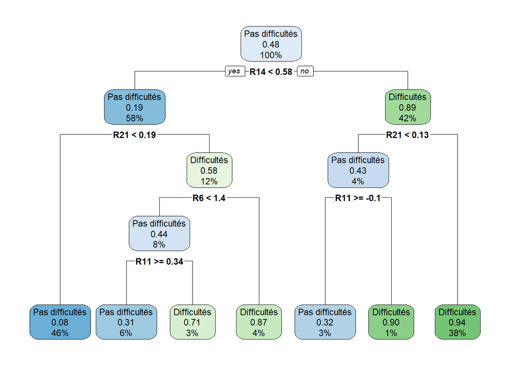

```r
arbre_class=rpart(DIFF~., data = def_finan)
rpart.plot(arbre_class)
```

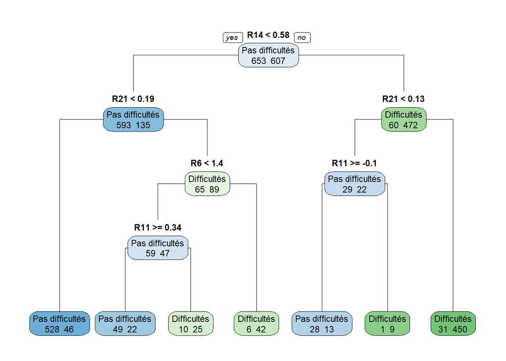

```r
rpart.plot(arbre_class, type = 1, extra = 1)
```

### Importance des variables

```r
arbre_class$variable.importance
```

```
##         R14         R11         R12          R4          R8          R1
## 309.6548279 262.9686014 262.7067693 227.5957240 223.0428994 182.7475599
##         R21         R18         R22          R6         R30         R32
##  87.7197089  51.8756260  45.4058947  42.1198922  40.6253424  24.2260051
##         R19          R7          R2          R5
##  11.2010769   8.7189568   0.6573294   0.4382196
```

```r
importance = round(arbre_class$variable.importance)
varimp = tibble(Variable = names(importance), Importance = importance)
```

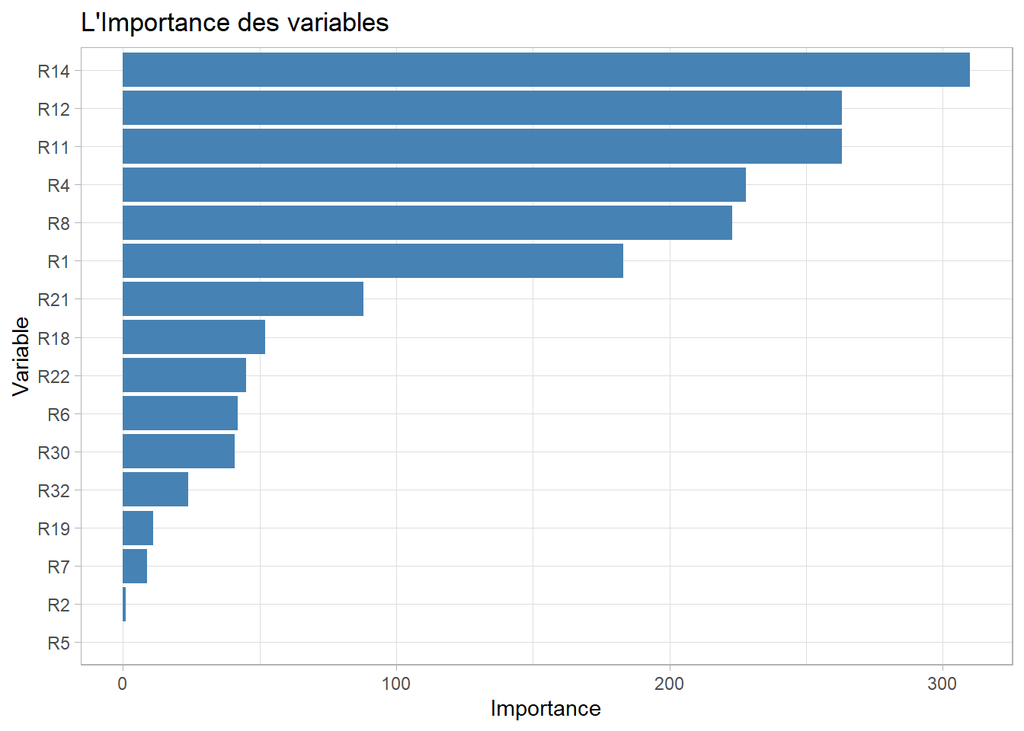

```r
varimp %>% ggplot(aes(fct_reorder(Variable, Importance), Importance))+
      geom_col(fill = "steelblue")+coord_flip()+
      labs(title = "L'Importance des variables",
           x = "Variable")+theme_light()
```

### Apprentissage vs Témoin

On va echantilloner notre base pour avoir un échantillon d’apprentissage et un échantillon témoin. On fait un tirage aléatoire et sans remise pour que 80% (seuil de base) des données constitue l’échantillon d’apprentissage. Et 20% l’échantillon de test.

```r
set.seed(200)
id_appren = sample(nrow(def_finan), floor(nrow(def_finan) * 0.80))

# Echantillon d'apprentissage
def_finan_appren = def_finan %>% slice(id_appren)

# Echantillon témoin
def_finan_test = def_finan %>% slice(-id_appren)

summary(def_finan_appren)
```

```
##               DIFF           R1               R2               R3
##  Pas difficultés:525   Min.   :0.1190   Min.   :0.0000   Min.   :-1.5060
##  Difficultés    :483   1st Qu.:0.3405   1st Qu.:0.3187   1st Qu.: 0.2230
##                        Median :0.5285   Median :0.5775   Median : 0.3646
##                        Mean   :0.5854   Mean   :0.5220   Mean   : 0.3787
##                        3rd Qu.:0.7853   3rd Qu.:0.7542   3rd Qu.: 0.5216
##                        Max.   :3.4940   Max.   :0.9980   Max.   : 0.9999
##        R4                R5                R6               R7
##  Min.   :-0.4940   Min.   :0.00006   Min.   :0.1800   Min.   :0.00005
##  1st Qu.: 0.0804   1st Qu.:0.20375   1st Qu.:0.5600   1st Qu.:0.32275
##  Median : 0.1635   Median :0.32900   Median :0.9055   Median :0.54450
##  Mean   : 0.2294   Mean   :0.35377   Mean   :1.0408   Mean   :0.64502
##  3rd Qu.: 0.3277   3rd Qu.:0.46825   3rd Qu.:1.3582   3rd Qu.:0.86400
##  Max.   : 1.1114   Max.   :2.79200   Max.   :4.3620   Max.   :3.11700
##        R8               R11               R12                R14
##  Min.   :-0.9330   Min.   :-0.9060   Min.   :-1.16300   Min.   :-0.6850
##  1st Qu.: 0.1370   1st Qu.:-0.0145   1st Qu.:-0.01798   1st Qu.: 0.2159
##  Median : 0.2820   Median : 0.2881   Median : 0.43785   Median : 0.4610
##  Mean   : 0.3880   Mean   : 0.2632   Mean   : 0.43170   Mean   : 0.7006
##  3rd Qu.: 0.5579   3rd Qu.: 0.5435   3rd Qu.: 0.86800   3rd Qu.: 1.0246
##  Max.   : 1.8494   Max.   : 2.2959   Max.   : 3.97150   Max.   : 5.1712
##       R17               R18               R19               R21
##  Min.   :0.00599   Min.   :0.00169   Min.   :0.01700   Min.   :0.00663
##  1st Qu.:0.04487   1st Qu.:0.02955   1st Qu.:0.09805   1st Qu.:0.08753
##  Median :0.06210   Median :0.05680   Median :0.15600   Median :0.17300
##  Mean   :0.06428   Mean   :0.07049   Mean   :0.18115   Mean   :0.28285
##  3rd Qu.:0.08153   3rd Qu.:0.09530   3rd Qu.:0.23600   3rd Qu.:0.34125
##  Max.   :0.12400   Max.   :0.30000   Max.   :1.14200   Max.   :5.07900
##       R22                R24              R28              R30
##  Min.   : 0.04939   Min.   :0.0141   Min.   :0.0347   Min.   :-1.05900
##  1st Qu.: 0.28305   1st Qu.:0.1378   1st Qu.:0.2577   1st Qu.: 0.05196
##  Median : 0.49695   Median :0.1880   Median :0.3280   Median : 0.16045
##  Mean   : 0.70072   Mean   :0.1982   Mean   :0.3217   Mean   : 0.14020
##  3rd Qu.: 0.81870   3rd Qu.:0.2460   3rd Qu.:0.3890   3rd Qu.: 0.26395
##  Max.   :13.67300   Max.   :0.7460   Max.   :0.5810   Max.   : 0.51320
##       R32               R36              R37
##  Min.   :-0.1620   Min.   :0.1180   Min.   :0.1600
##  1st Qu.: 0.1710   1st Qu.:0.7735   1st Qu.:0.4630
##  Median : 0.2676   Median :1.0750   Median :0.5780
##  Mean   : 0.2510   Mean   :1.1634   Mean   :0.6185
##  3rd Qu.: 0.3387   3rd Qu.:1.4572   3rd Qu.:0.7292
##  Max.   : 0.5626   Max.   :5.0430   Max.   :2.3490
```

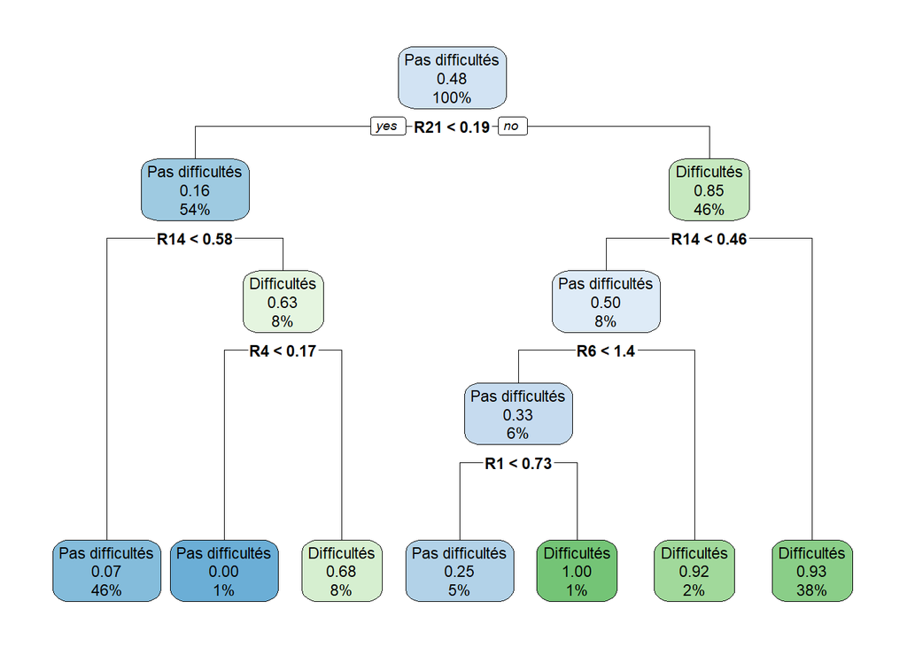

```r
arbre_appren=rpart(DIFF~., data = def_finan_appren)
rpart.plot(arbre_appren)
```

### Validation du modèle

```r
that = arbre_appren %>% predict(newdata = def_finan_test, type='class')
head(that)
```

```
##               1               2               3               4               5
## Pas difficultés Pas difficultés     Difficultés Pas difficultés     Difficultés
##               6
## Pas difficultés
## Levels: Pas difficultés Difficultés
```

Erreur non-normalisée

```r
err_nn = nrow(def_finan_test)
sqrt(sum(that!= def_finan_test$DIFF)^2/err_nn)
```

```
## [1] 2.015811
```

Erreur normalisée :

```r
cible = def_finan_test$DIFF == "Difficultés"
100*sum(that[cible] != def_finan_test$DIFF[cible])/sum(cible)
```

```
## [1] 14.51613
```

## Comparaison des modèles logistique

```r
def_finan_appren$DIFF = factor(def_finan_appren$DIFF,labels=c("Pas difficultés", "Difficultés"))
model_log <- glm(DIFF ~ R1 + R3 + R8 + R14 + R17 + R22 + R28 + R30 + R36 + R37, data = def_finan_appren, family = binomial)
summary(model_log)
```

```
##
## Call:
## glm(formula = DIFF ~ R1 + R3 + R8 + R14 + R17 + R22 + R28 + R30 +
##     R36 + R37, family = binomial, data = def_finan_appren)
##
## Deviance Residuals:
##     Min       1Q   Median       3Q      Max
## -4.2462  -0.3595  -0.0941   0.2609   3.0582
##
## Coefficients:
##             Estimate Std. Error z value Pr(>|z|)
## (Intercept)  -9.9524     1.6129  -6.170 6.82e-10 ***
## R1           11.1091     1.2135   9.155  < 2e-16 ***
## R3            6.7624     1.3553   4.990 6.05e-07 ***
## R8           -3.8009     1.0772  -3.529 0.000418 ***
## R14           1.2324     0.5364   2.298 0.021581 *
## R17          30.9474     6.0003   5.158 2.50e-07 ***
## R22           2.4138     0.8815   2.738 0.006178 **
## R28         -10.2199     2.6410  -3.870 0.000109 ***
## R30           9.5820     3.5334   2.712 0.006691 **
## R36           1.4660     0.4121   3.558 0.000374 ***
## R37          -2.4454     1.0460  -2.338 0.019396 *
## ---
## Signif. codes:  0 '***' 0.001 '**' 0.01 '*' 0.05 '.' 0.1 ' ' 1
##
## (Dispersion parameter for binomial family taken to be 1)
##
##     Null deviance: 1395.63  on 1007  degrees of freedom
## Residual deviance:  535.74  on  997  degrees of freedom
## AIC: 557.74
##
## Number of Fisher Scoring iterations: 8
```

```r
tstar <- predict(model_log, newdata = def_finan_test)
muhat = exp(tstar)/(1+ exp(tstar))
that2 <- factor(ifelse(as.numeric(muhat > 0.5), "Oui", "Non"))
```